# Project: prosperLoanData Dataset

## By: Shaimaa Eid

### The Dataset

This data set contains 113,937 loans with 81 variables on each loan, including loan amount, borrower rate (or interest rate), current loan status, borrower income, and many others. After **Data cleaning** and removing unwanted variables we hae 16 variables and 82682 rows. in the following analysis I will examine the relation between loan status and other variables in an attampt to know which loans get paid and which has a potential risk of not getting paid.

### Feature(s) of interest

Created,Term, Status,BorrowerRate,Yield, Loss, Return, Category, BorrowerState, Occupation, EmploymentStatus.

## Exploratory Data Analysis

In this section I'm trying to answer the following questions:

1. How many loans initiated per year?
2. How many Past due loans?
3. What duration is most frequent?
4. Who got the loans?
5. Who is not paying loans?

### How many loans initiated per year?

```
The year '2013' has the max number of loans created over all years, '2009' is the lowest in number of loans.
```

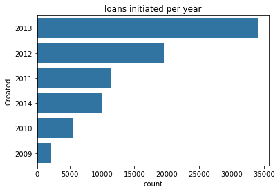

```python
base_color = sb.color_palette()[0]

# Plot 'Created' count on a Horizontal bar chart
year_order = loans['Created'].value_counts().index
sb.countplot(data=loans, y='Created', color=base_color, order=year_order);
plt.title('loans initiated per year');
print("The year '2013' has the max number of loans created over all years, '2009' is the lowest in number of loans.")
```

### How many Past due loans?

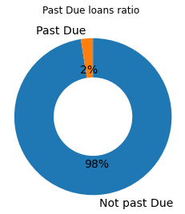

```python
# plot pie chart
plt.pie(loan_past, labels = ['Not past Due','Past Due'], startangle = 90, counterclock = False, autopct='%1.0f%%',wedgeprops = {'width' : 0.5},textprops={'fontsize': 14});
plt.axis('square');
plt.title('Past Due loans ratio \n');
```

> Only 2044 loans are Past due with a 2% percent of total loans.

### What duration is most frequent?

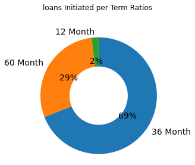

```python
plt.pie(terms_count, labels = ['36 Month','60 Month', '12 Month'], startangle = 90, counterclock = False, autopct='%1.0f%%',wedgeprops = {'width' : 0.5},textprops={'fontsize': 14});
plt.axis('square');
plt.title('loans Initiated per Term Ratios \n \n');
```

> 69% of loans were for 36 months of duration.

## Who got the loans?

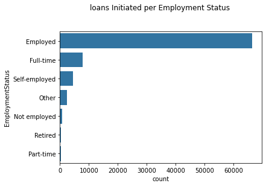

```python
# Plot 'Terms' count on a Horizontal bar chart
emp_count = loans['EmploymentStatus'].value_counts()
sb.countplot(data=loans, y='EmploymentStatus', color=base_color, order=emp_count.index);
plt.title('loans Initiated per Employment Status \n \n');
```

> Majority of loans were given to 'Employed' borrowers, 'Part-time' borrowers has the lowest loans.

### Who is not paying loans?

#### Past Due by Employement

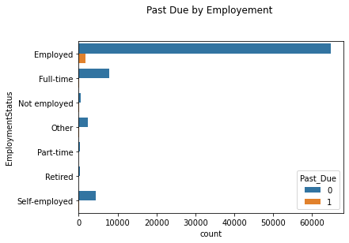

```python
sb.countplot(data = loans, y = 'EmploymentStatus', hue = 'Past_Due');
plt.title('Past Due by Employement \n \n');
```